# *Rana Musca*

Hannah Irish

2023-01-25

```r
knitr::opts_chunk$set(echo = TRUE)
library(tidyverse)
library(here)
library(janitor)
library(cowplot)
library(readxl)
library(lubridate)
```

# **Investigation of *Rana Musca***

# **Introduction**

The data in this project is from the Sierra Lakes Inventory Project (SLIP), which was a survey of aquatic communities in the Southern Sierra Nevada, with the goal of describing the impact of non-native fish on lake communities.

The data contains counts, life stages, and various other characteristics for the aquatic species present in these water bodies.

# **Methods**

This reads in data using read_excel:

```r
sierra_amphibians <- read_excel(here("task1","sierra_amphibians.xlsx"))
```

## Visualizing Life Stages of *Rana muscosa*

This code uses lubridate to turn the date into a recognizable date and extracting the year using mutate. Drop nas in order to create graph using drop_na(). Use filter(), group_by(), and summarize() to isolate just the yellow-legged frogs that are not in stage “EggMass” so I may total the frogs by year:

```r
##change given years to usable years using lubridate

sierra_amphibians_mod <- sierra_amphibians %>%
  mutate("date" = ymd(survey_date))

sierra_amphibians_year <- sierra_amphibians_mod %>%
  mutate("data_year" = year(date))

sier_amph_no_nas <- sierra_amphibians_year %>%
  drop_na()

yellow_frogs <- sier_amph_no_nas %>%
 filter(amphibian_species=="RAMU", amphibian_life_stage != "EggMass") %>%
  group_by(data_year, amphibian_life_stage) %>%
  summarize(total = sum(amphibian_number))
```

This code creates a plot of the yellow-legged frogs versus year and lifestage to see how the relative number differs over time:

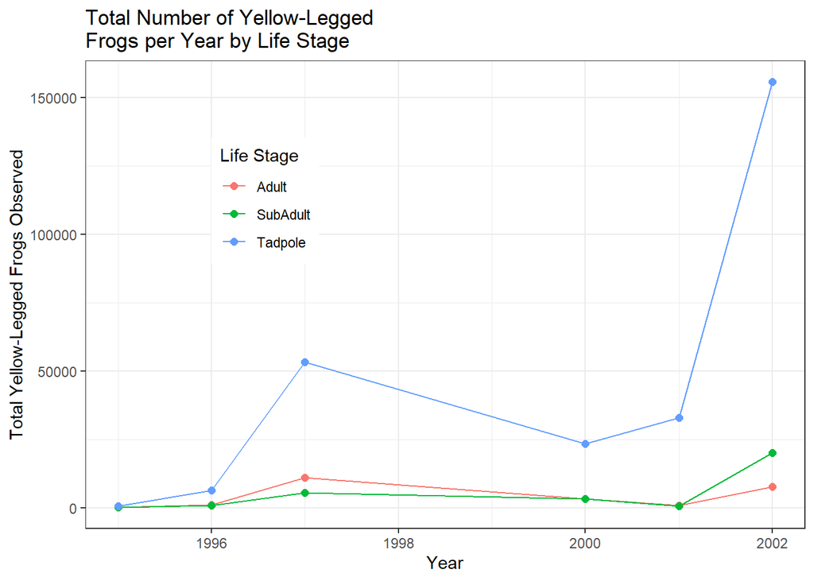

Figure 1: Trends in the total number of the Yellow-Legged Frogs by life stage over the course of the data collection.

```r
yfrog_plot <- ggplot(data = yellow_frogs, aes(x = data_year, y = total)) +
  geom_path(aes(color=amphibian_life_stage)) +
  geom_point(size=2, aes(color=amphibian_life_stage)) +
  labs(color="Life Stage",title = "Total Number of Yellow-Legged \nFrogs per Year by Life Stage", x="Year", y="Total Yellow-Legged Frogs Observed") +
  theme(plot.title = element_text(hjust=0.5))+
  theme_bw() +
  theme(legend.position = c(0.25, 0.7))



yfrog_plot
```

## Visualizing *Rana muscosa* by Lake

This code isolates just subadult and adult yellow-legged frogs and find the lakes with the top 5 total amphibians. It adds “Lake” to the Lake ID to make a factor and organize by total amphibian (Yellow-legged Frog) count:

```r
sierra_adults <- sierra_amphibians %>%
  filter(amphibian_species == "RAMU", amphibian_life_stage %in% c("Adult", "SubAdult")) %>%
  group_by(lake_id) %>%
  summarize(total_count = sum(amphibian_number))

sierra_adults_sorted <- sierra_adults %>%
  arrange(desc(total_count)) %>%
  slice(1:5) %>%
  mutate(lake_id_char=as.character(lake_id)) %>%
  mutate(lake_id_char_mod = paste0("Lake ", lake_id_char))

sierra_adults_sorted$lake_id_char_mod <- factor(sierra_adults_sorted$lake_id_char_mod)
```

This code creates plot of the lakes with the top total counts of the Yellow-legged frogs:

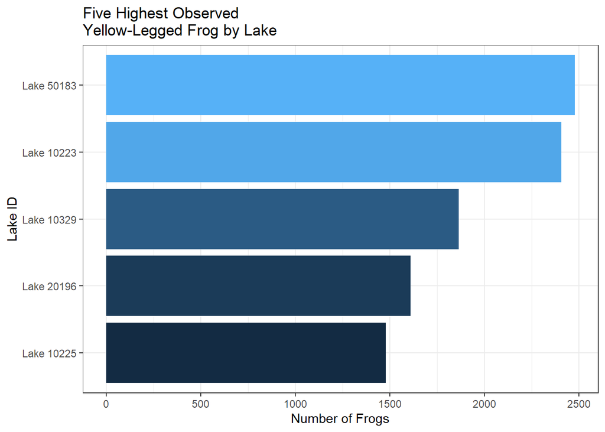

Figure 2: The lakes with the top 5 highest counts of SubAdult and Adult Yellow-Legged Frogs

```r
top_plot <- ggplot(data = sierra_adults_sorted, aes(x = fct_reorder(lake_id_char_mod, total_count), y = total_count)) +
  geom_col(aes(fill=total_count), show.legend = FALSE) +
  coord_flip() +
  scale_color_brewer()+
  labs(title="Five Highest Observed \nYellow-Legged Frog by Lake") +
  ylab("Number of Frogs") +
  xlab("Lake ID") +
  theme(plot.title = element_text(hjust=0.5)) +
  theme_bw()

top_plot
```

# **Results**

This code arranges my two plots in a grid:

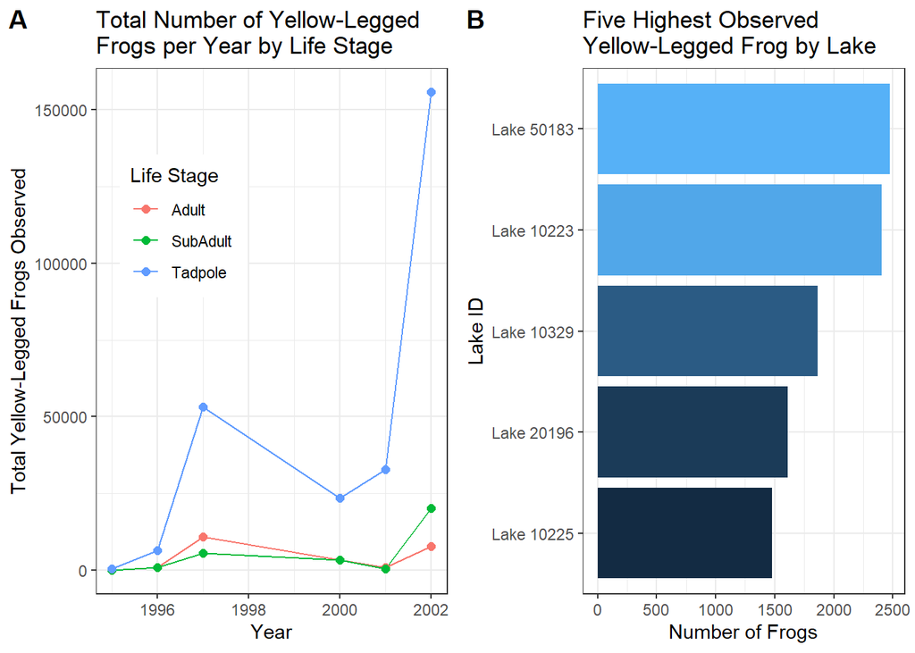

```r
plot_grid(yfrog_plot, top_plot, labels="AUTO")
```

# **References**

Data Source:

Knapp, R.A., C. Pavelka, E.E. Hegeman, and T.C. Smith. 2020. The Sierra Lakes Inventory Project: Non-Native fish and community composition of lakes and ponds in the Sierra Nevada, California ver 2. Environmental Data Initiative. https://doi.org/10.6073/pasta/d835832d7fd00d9e4466e44eea87fab3